# Tidymodels live session - EcoDataScience

Gavin McDonald - Environmental Markets Solutions Lab (emLab)

11/19/2019

# Introduction

This live session has been adapted from from Edgar Ruiz’s [A Gentle Introduction to tidymodels](https://rviews.rstudio.com/2019/06/19/a-gentle-intro-to-tidymodels/). We will run through an end-to-end modeling examples. The first will be a regression example using the `Sacramento` housing prices dataset, and the second will be a classification example using the `GermanCredit` credit score dataset.

I will briefly touch on important steps of the predictive modeling process, but this is *not* mean to be a comprehensive instruction on predictive modeling (*a.k.a.* machine learning). This tutorial is rather just meant to give a flavor of what’s possible using the new `tidymodels` universe of packages. For a much more detailed overview, see Max Kuhn’s fantastic [Applied Predictive Modeling](http://appliedpredictivemodeling.com).

# Install necessary pacakges

```r
# pacman will help us install any necessary packages
if (!require("pacman")) install.packages("pacman")
# pacman::p_load checks to see if this packages are installed, and installs them if not
pacman::p_load(tidymodels, ranger, randomForest, caret)
```

# Load packages

Load the tidymodels library. This loads a collection of both tidymodels packages, and select tidyverse packages like dplyr, purrr, ggplot2. We will also load caret since it has some very [nice datasets](https://topepo.github.io/caret/data-sets.html) for regression and classification exercises.

```r
library(tidymodels)
library(caret)
# Set random number seed to get consistent results
set.seed(101)
```

# Regression example using `Sacramento`

## Load dataset

```r
data(Sacramento)

Sacramento
```

|  | city | zip | beds | baths | sqft | type | price | latitude | longitude |
| --- | --- | --- | --- | --- | --- | --- | --- | --- | --- |
| 1 | SACRAMENTO | z95838 | 2 | 1.0 | 836 | Residential | 59222 | 38.63191 | -121.4349 |
| 2 | SACRAMENTO | z95823 | 3 | 1.0 | 1167 | Residential | 68212 | 38.47890 | -121.4310 |
| 3 | SACRAMENTO | z95815 | 2 | 1.0 | 796 | Residential | 68880 | 38.61830 | -121.4438 |
| 4 | SACRAMENTO | z95815 | 2 | 1.0 | 852 | Residential | 69307 | 38.61684 | -121.4391 |
| 5 | SACRAMENTO | z95824 | 2 | 1.0 | 797 | Residential | 81900 | 38.51947 | -121.4358 |
| 6 | SACRAMENTO | z95841 | 3 | 1.0 | 1122 | Condo | 89921 | 38.66260 | -121.3278 |
| 7 | SACRAMENTO | z95842 | 3 | 2.0 | 1104 | Residential | 90895 | 38.68166 | -121.3517 |
| 8 | SACRAMENTO | z95820 | 3 | 1.0 | 1177 | Residential | 91002 | 38.53509 | -121.4814 |
| 9 | RANCHO_CORDOVA | z95670 | 2 | 2.0 | 941 | Condo | 94905 | 38.62119 | -121.2706 |
| 10 | RIO_LINDA | z95673 | 3 | 2.0 | 1146 | Residential | 98937 | 38.70091 | -121.4430 |

[output cut: 922 more lines]

## Data sampling

The first step in the modeling process is to split your data into separate training and testing datasets. The model will be trained using the training dataset, and the testing dataset will not be used until you are ready to assess model performance. The `rsample::initial_split` function helps with this initial splitting of the data. The `rsample` includes many other helpful functions for splitting the data for cross-validation, bootstrapping, etc.

```r
# Split the dataset, using 75% of the data for training and 25% for testing
housing_split <- Sacramento %>%
  as_tibble() %>%
  dplyr::select(price,type,sqft,beds,baths,latitude,longitude) %>%
  initial_split(prop = 0.75)

# This rsplit object tells you how many observations are used for training, how many for testing, and how many total
housing_split
```

```
## <699/233/932>
```

```r
# The training function can be used to extract the training data from the rsplit object
housing_training <- housing_split %>%
  training()

housing_training
```

| price | type | sqft | beds | baths | latitude | longitude |
| --- | --- | --- | --- | --- | --- | --- |
| 59222 | Residential | 836 | 2 | 1.0 | 38.63191 | -121.4349 |
| 69307 | Residential | 852 | 2 | 1.0 | 38.61684 | -121.4391 |
| 89921 | Condo | 1122 | 3 | 1.0 | 38.66260 | -121.3278 |
| 91002 | Residential | 1177 | 3 | 1.0 | 38.53509 | -121.4814 |
| 98937 | Residential | 1146 | 3 | 2.0 | 38.70091 | -121.4430 |
| 100309 | Residential | 909 | 3 | 2.0 | 38.63766 | -121.4515 |
| 106250 | Residential | 1289 | 3 | 2.0 | 38.47075 | -121.4589 |
| 106852 | Residential | 871 | 1 | 1.0 | 38.61870 | -121.4358 |
| 110700 | Condo | 1134 | 2 | 2.0 | 38.70005 | -121.3513 |
| 116250 | Condo | 795 | 2 | 1.0 | 38.67978 | -121.3141 |

[output cut: 689 more lines]

```r
# The testing function can be used to extract the testing data from the rsplit object
housing_testing <- housing_split %>%
  testing()

housing_testing
```

| price | type | sqft | beds | baths | latitude | longitude |
| --- | --- | --- | --- | --- | --- | --- |
| 68212 | Residential | 1167 | 3 | 1.0 | 38.47890 | -121.4310 |
| 68880 | Residential | 796 | 2 | 1.0 | 38.61830 | -121.4438 |
| 81900 | Residential | 797 | 2 | 1.0 | 38.51947 | -121.4358 |
| 90895 | Residential | 1104 | 3 | 2.0 | 38.68166 | -121.3517 |
| 94905 | Condo | 941 | 2 | 2.0 | 38.62119 | -121.2706 |
| 107502 | Residential | 1020 | 3 | 1.0 | 38.48221 | -121.4926 |
| 108750 | Residential | 1022 | 2 | 2.0 | 38.67291 | -121.3593 |
| 113263 | Residential | 844 | 2 | 1.0 | 38.68959 | -121.4522 |
| 122000 | Residential | 1118 | 3 | 2.0 | 38.70785 | -121.3207 |
| 122682 | Residential | 1329 | 4 | 2.0 | 38.46817 | -121.4441 |

[output cut: 223 more lines]

## Data pre-processing

After splitting the data, we will do some data processing. To do this, we will use the `recipe` package. A recipe is a blueprint for how data will be processed. By creating a blueprint, rather than processing data directly, we can apply the same blueprint to training and testing datasets. Importantly, the recipe is defined using only data from the training dataset, which will allow us to see how well the model performs using the testing dataset. Recipe steps can be defined using pipes with a number of sequential steps - there are many many options for recipe steps.

```r
housing_recipe <- housing_training %>%
  # Specify regression model formula
  recipe(price ~.)  %>%
  # step_corr removes highly correlated variables
  step_corr(all_numeric()) %>%
  # step_center normalizes data to have a mean of 0
  step_center(all_numeric(), -all_outcomes()) %>%
  # step_scale normalizes data to have a standard deviation of 0
  step_scale(all_numeric(), -all_outcomes()) %>%
  # Create dummy variable columns for all factor columns
  step_dummy(all_predictors(),-all_numeric())

housing_recipe
```

```
## Data Recipe
##
## Inputs:
##
##       role #variables
##    outcome          1
##  predictor          6
##
## Operations:
##
## Correlation filter on all_numeric()
## Centering for all_numeric(), -all_outcomes()
## Scaling for all_numeric(), -all_outcomes()
## Dummy variables from all_predictors(), -all_numeric()
```

```r
housing_recipe_prepped <- housing_recipe %>%
  # prep trains the recipe using the training dataset
  prep()

housing_recipe_prepped
```

```
## Data Recipe
##
## Inputs:
##
##       role #variables
##    outcome          1
##  predictor          6
##
## Training data contained 699 data points and no missing data.
##
## Operations:
##
## Correlation filter removed no terms [trained]
## Centering for sqft, beds, baths, latitude, longitude [trained]
## Scaling for sqft, beds, baths, latitude, longitude [trained]
## Dummy variables from type [trained]
```

```r
# Use use the juice function to apply the prepped recipe to the training dataset
housing_training_juiced <- juice(housing_recipe_prepped)

housing_training_juiced
```

| sqft | beds | baths | latitude | longitude | price | type_Multi_Family | type_Residential |
| --- | --- | --- | --- | --- | --- | --- | --- |
| -1.1453592741 | -1.4628374 | -1.44575774 | 0.275420825 | -0.5352208720 | 59222 | 0 | 1 |
| -1.1237127874 | -1.4628374 | -1.44575774 | 0.164364353 | -0.5654235676 | 69307 | 0 | 1 |
| -0.7584283249 | -0.3241700 | -1.44575774 | 0.501408003 | 0.2226140969 | 89921 | 0 | 0 |
| -0.6840185270 | -0.3241700 | -1.44575774 | -0.437710803 | -0.8642724106 | 91002 | 0 | 1 |
| -0.7259585949 | -0.3241700 | -0.09380502 | 0.783608406 | -0.5925543228 | 98937 | 0 | 1 |
| -1.0465971787 | -0.3241700 | -0.09380502 | 0.317772245 | -0.6530092615 | 100309 | 0 | 1 |
| -0.5324931203 | -0.3241700 | -0.09380502 | -0.911648975 | -0.7053738133 | 106250 | 0 | 1 |
| -1.0980075845 | -2.6015047 | -1.44575774 | 0.178086213 | -0.5419734784 | 106852 | 0 | 1 |
| -0.7421934599 | -1.4628374 | -0.09380502 | 0.777288837 | 0.0565240446 | 110700 | 0 | 0 |
| -1.2008283962 | -1.4628374 | -1.44575774 | 0.627954047 | 0.3197553660 | 116250 | 0 | 0 |

[output cut: 689 more lines]

```r
# We use the bake function to apply the prepped recipe to the testing dataset
housing_testing_baked <- housing_recipe_prepped %>%
  bake(housing_testing)

housing_testing_baked
```

| price | sqft | beds | baths | latitude | longitude | type_Multi_Family | type_Residential |
| --- | --- | --- | --- | --- | --- | --- | --- |
| 68212 | -0.697547581 | -0.3241700 | -1.44575774 | -0.851576247 | -0.5079627091 | 0 | 1 |
| 68880 | -1.199475491 | -1.4628374 | -1.44575774 | 0.175191585 | -0.5986415781 | 0 | 1 |
| 81900 | -1.198122585 | -1.4628374 | -1.44575774 | -0.552774088 | -0.5415133952 | 0 | 1 |
| 90895 | -0.782780622 | -0.3241700 | -0.09380502 | 0.641823216 | 0.0535016515 | 0 | 1 |
| 94905 | -1.003304205 | -1.4628374 | -0.09380502 | 0.196426219 | 0.6278978906 | 0 | 0 |
| 107502 | -0.896424677 | -0.3241700 | -1.44575774 | -0.827174464 | -0.9438031086 | 0 | 1 |
| 108750 | -0.893718867 | -1.4628374 | -0.09380502 | 0.577412230 | -0.0005404345 | 0 | 1 |
| 113263 | -1.134536031 | -1.4628374 | -1.44575774 | 0.700246080 | -0.6580984901 | 0 | 1 |
| 122000 | -0.763839947 | -0.3241700 | -0.09380502 | 0.834739460 | 0.2729118132 | 0 | 1 |
| 122682 | -0.478376904 | 0.8144974 | -0.09380502 | -0.930600315 | -0.6002837214 | 0 | 1 |

[output cut: 223 more lines]

## Model training

Next, we will use the `parsnip` package to define a number of models. Generally, we use parsnip to define 3 things about our model:

1. The type of model (e.g., linear regression or random forest)
2. the mode of the model (e.g., regression or classification)
3. The engine for the model (e.g., `ranger` or `randomForest`)

After we’ve defined the model in this way, we can use the `fit` function to fit the model.

```r
# Define and fit a linear regression model
housing_model_lm <- linear_reg() %>%
  set_engine("lm")

housing_model_lm
```

```
## Linear Regression Model Specification (regression)
##
## Computational engine: lm
```

```r
housing_fit_lm <- housing_model_lm %>%
  fit(price ~ ., data = housing_training_juiced)

housing_fit_lm
```

```
## parsnip model object
##
##
## Call:
## stats::lm(formula = formula, data = data)
##
## Coefficients:
##       (Intercept)               sqft               beds
##            214805             108859             -21365
##             baths           latitude          longitude
##              4012               5449              22289
## type_Multi_Family   type_Residential
##            -28780              35319
```

```r
# Define and fit a random forest regression model using the randomForest engine/package
housing_model_randomForest <-  rand_forest(trees = 100, mode = "regression") %>%
  set_engine("randomForest")

housing_model_randomForest
```

```
## Random Forest Model Specification (regression)
##
## Main Arguments:
##   trees = 100
##
## Computational engine: randomForest
```

```r
housing_fit_randomForest <- housing_model_randomForest %>%
  fit(price ~ ., data = housing_training_juiced)

housing_fit_randomForest
```

```
## parsnip model object
##
##
## Call:
##  randomForest(x = as.data.frame(x), y = y, ntree = ~100)
##                Type of random forest: regression
##                      Number of trees: 100
## No. of variables tried at each split: 2
##
##           Mean of squared residuals: 6375931082
##                     % Var explained: 64.88
```

```r
# Define and fit a random forest regression model using the ranger engine/package
housing_model_ranger <- rand_forest(trees = 100, mode = "regression") %>%
  set_engine("ranger")

housing_model_ranger
```

```
## Random Forest Model Specification (regression)
##
## Main Arguments:
##   trees = 100
##
## Computational engine: ranger
```

```r
housing_fit_ranger <- housing_model_ranger %>%
  fit(price ~ ., data = housing_training_juiced)

housing_fit_ranger
```

```
## parsnip model object
##
## Ranger result
##
## Call:
##  ranger::ranger(formula = formula, data = data, num.trees = ~100,      num.threads = 1, verbose = FALSE, seed = sample.int(10^5,          1))
##
## Type:                             Regression
## Number of trees:                  100
## Sample size:                      699
## Number of independent variables:  7
## Mtry:                             2
## Target node size:                 5
## Variable importance mode:         none
## Splitrule:                        variance
## OOB prediction error (MSE):       6535290209
## R squared (OOB):                  0.640522
```

Once we have the model fits, we can use the `predict` function to generate our predictions for our testing dataset. The predict function always produces a dataframe with the same number of rows as observations. Because of this, `bind_cols` can be used to bind the predictions to the original dataframe

```r
# Generate predictions for our testing using the ranger model
predict(housing_fit_ranger, housing_testing_baked)
```

| .pred |
| --- |
| 147818.7 |
| 102903.6 |
| 104999.0 |
| 165310.4 |
| 166154.9 |
| 150233.8 |
| 154082.3 |
| 121467.5 |
| 159568.6 |
| 180949.1 |

[output cut: 223 more lines]

```r
# Add these ranger predictions to the testing dataset
housing_fit_ranger %>%
  predict(housing_testing_baked) %>%
  bind_cols(housing_testing_baked)
```

| .pred | price | sqft | beds | baths | latitude | longitude | type_Multi_Family | type_Residential |
| --- | --- | --- | --- | --- | --- | --- | --- | --- |
| 147818.7 | 68212 | -0.697547581 | -0.3241700 | -1.44575774 | -0.851576247 | -0.5079627091 | 0 | 1 |
| 102903.6 | 68880 | -1.199475491 | -1.4628374 | -1.44575774 | 0.175191585 | -0.5986415781 | 0 | 1 |
| 104999.0 | 81900 | -1.198122585 | -1.4628374 | -1.44575774 | -0.552774088 | -0.5415133952 | 0 | 1 |
| 165310.4 | 90895 | -0.782780622 | -0.3241700 | -0.09380502 | 0.641823216 | 0.0535016515 | 0 | 1 |
| 166154.9 | 94905 | -1.003304205 | -1.4628374 | -0.09380502 | 0.196426219 | 0.6278978906 | 0 | 0 |
| 150233.8 | 107502 | -0.896424677 | -0.3241700 | -1.44575774 | -0.827174464 | -0.9438031086 | 0 | 1 |
| 154082.3 | 108750 | -0.893718867 | -1.4628374 | -0.09380502 | 0.577412230 | -0.0005404345 | 0 | 1 |
| 121467.5 | 113263 | -1.134536031 | -1.4628374 | -1.44575774 | 0.700246080 | -0.6580984901 | 0 | 1 |
| 159568.6 | 122000 | -0.763839947 | -0.3241700 | -0.09380502 | 0.834739460 | 0.2729118132 | 0 | 1 |
| 180949.1 | 122682 | -0.478376904 | 0.8144974 | -0.09380502 | -0.930600315 | -0.6002837214 | 0 | 1 |

[output cut: 223 more lines]

```r
# Save this combined dataframe for later
housing_ranger_predict <- housing_fit_ranger %>%
  predict(housing_testing_baked) %>%
  bind_cols(housing_testing_baked) %>%
  # Add a column for model name
  mutate(model_name = "ranger")

# Let's do the same thing for the linerar regression model
housing_lm_predict <- housing_fit_lm %>%
  predict(housing_testing_baked) %>%
  bind_cols(housing_testing_baked) %>%
  mutate(model_name = "lm")

# Let's do the same thing for the randomForest model
housing_randomForest_predict <- housing_fit_randomForest %>%
  predict(housing_testing_baked) %>%
  bind_cols(housing_testing_baked) %>%
  mutate(model_name = "randomForest")

# Let's combine all of these datasets so we can look at them side-by-side
housing_all_predict <- bind_rows(housing_lm_predict,
                              housing_ranger_predict,
                              housing_randomForest_predict)
```

Let’s just look and see how our predictions line up with the observed values in our testing dataset.

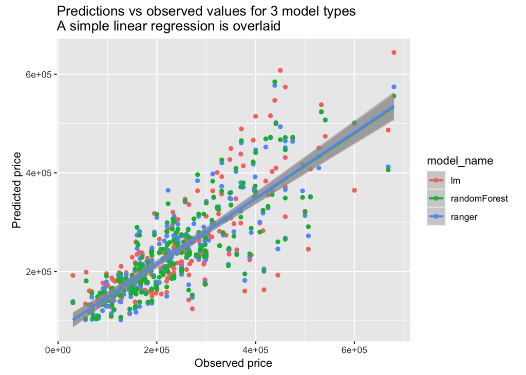

```r
housing_all_predict %>%
  ggplot(aes(x = price,y=.pred,color=model_name)) +
  geom_point() +
  geom_smooth(method = "lm") +
  labs(x = "Observed price",
       y = "Predicted price",
       title = "Predictions vs observed values for 3 model types\nA simple linear regression is overlaid") +
  coord_equal()
```

## Model performance assessment

Using our predictions from the `parsnip` package, we can use the `yardstick` package to generate model performance metrics. This can be done using the `metrics` function, which generates a default metric set (for a regression model, these are root mean squared error or `rsme`, r-squared or `rsq`, and mean absolute error or `mae`; for a classification model, these are `accuracy` and Kappa or `kap`). You can also define a custom set of metrics using `metric_set`, and there are also individual functions for all metric types.

```r
housing_ranger_predict %>%
  # Here we use the metric functions and must define the truth value and the estimated prediction
  metrics(truth = price, estimate = .pred)
```

| .metric | .estimator | .estimate |
| --- | --- | --- |
| rmse | standard | 65871.069573 |
| rsq | standard | 0.696223 |
| mae | standard | 48713.212457 |

When the predictions are in a dataframe, we can group by model type and calculat metrics by group

```r
housing_all_predict%>%
  group_by(model_name) %>%
  metrics(truth = price, estimate = .pred)
```

| model_name | .metric | .estimator | .estimate |
| --- | --- | --- | --- |
| lm | rmse | standard | 7.130077e+04 |
| randomForest | rmse | standard | 6.556520e+04 |
| ranger | rmse | standard | 6.587107e+04 |
| lm | rsq | standard | 6.437460e-01 |
| randomForest | rsq | standard | 6.998976e-01 |
| ranger | rsq | standard | 6.962230e-01 |
| lm | mae | standard | 5.394846e+04 |
| randomForest | mae | standard | 4.857134e+04 |
| ranger | mae | standard | 4.871321e+04 |

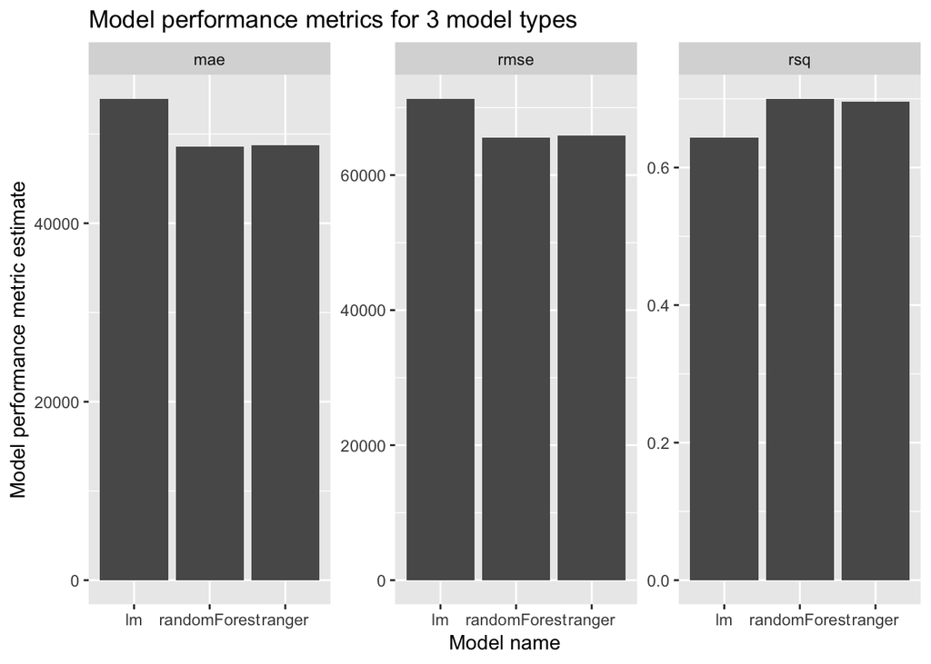

```r
housing_all_predict%>%
  group_by(model_name) %>%
  metrics(truth = price, estimate = .pred)%>%
  ggplot(aes(x = model_name, y = .estimate)) +
  geom_bar(stat="identity") +
  facet_wrap(.~.metric,scales="free") +
  labs(x = "Model name",
       y = "Model performance metric estimate",
       title = "Model performance metrics for 3 model types")
```

We can also do what we just did in a much more tidy fashion, while also keeping the model specifications, model fits, model predictions, and model metrics all in a single dataframe. This ensures that things stay together, and makes it very easy to extract summary statistics or plots. `purrr::map` and list columns makes this all possible. We could apply this same approach to build and test many models for cross-validation, for hyperparameter tuning, etc.

```r
# Define a tibble using model names and their associated specifications
all_models <-
  tibble(model_name = "lm",
         model = list(housing_model_lm)) %>%
  add_row(model_name = "ranger",
          model = list(housing_model_ranger)) %>%
  add_row(model_name = "randomForest",
          model = list(housing_model_randomForest))

all_models
```

| model_name | model |
| --- | --- |
| lm |  |
| ranger |  |
| randomForest |  |

```r
all_model_results <- all_models %>%
  # Add a column for model fits
  mutate(model_fit = purrr::map(model,
                                ~fit(.x, price ~ ., data = housing_training_juiced)),
         # Add a column for predictions
         model_predictions = purrr::map(model_fit,
                                        ~.x %>%
                                          predict(housing_testing_baked) %>%
                                          bind_cols(housing_testing_baked)),
         # Add a column for model metrics
         model_metrics = purrr::map(model_predictions,
                                    ~metrics(.x, truth = price, estimate = .pred)))

all_model_results
```

| model_name | model | model_fit | model_predictions | model_metrics |
| --- | --- | --- | --- | --- |
| lm |  |  |  |  |
| ranger |  |  |  |  |
| randomForest |  |  |  |  |

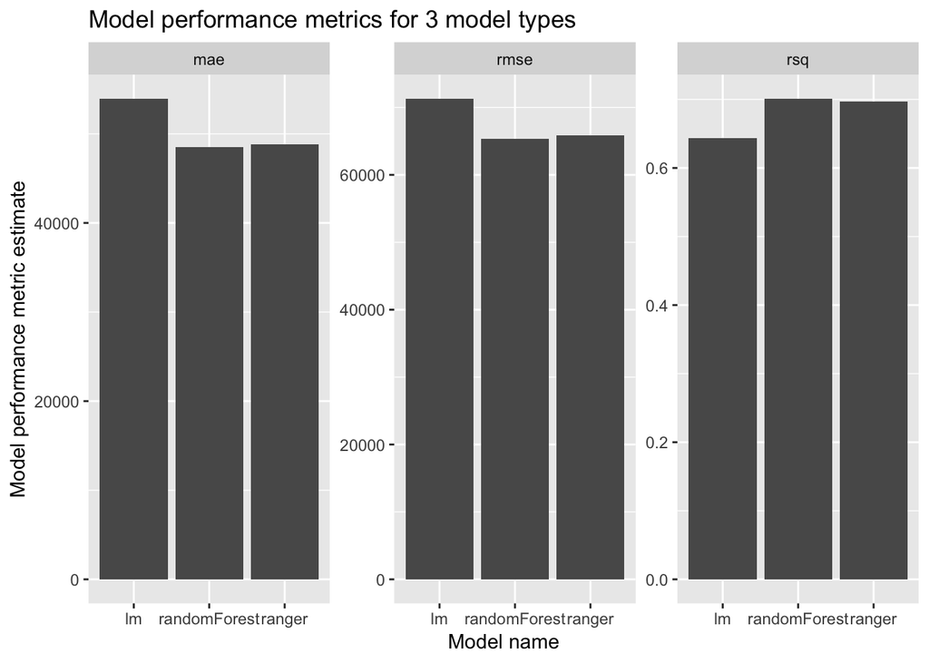

```r
# This plot is the same as the one we made above
all_model_results %>%
  unnest(model_metrics) %>%
  ggplot(aes(x = model_name, y = .estimate)) +
  geom_bar(stat="identity") +
  facet_wrap(.~.metric,scales="free") +
  labs(x = "Model name",
       y = "Model performance metric estimate",
       title = "Model performance metrics for 3 model types")
```

# Classification example using `GermanCredit`

Let’s also go through a classification example using the `GermanCredit` dataset from `caret`. Now we will try to predict credit rating (good or bad) using a number of predictors.

## Load packages

```r
data(GermanCredit)

GermanCredit
```

| Duration | Amount | InstallmentRatePercentage | ResidenceDuration | Age | NumberExistingCredits | NumberPeopleMaintenance | Telephone | ForeignWorker | Class | CheckingAccountStatus.lt.0 | CheckingAccountStatus.0.to.200 | CheckingAccountStatus.gt.200 | CheckingAccountStatus.none | CreditHistory.NoCredit.AllPaid | CreditHistory.ThisBank.AllPaid | CreditHistory.PaidDuly | CreditHistory.Delay | CreditHistory.Critical | Purpose.NewCar | Purpose.UsedCar | Purpose.Furniture.Equipment | Purpose.Radio.Television | Purpose.DomesticAppliance | Purpose.Repairs | Purpose.Education | Purpose.Vacation | Purpose.Retraining | Purpose.Business | Purpose.Other | … |
| --- | --- | --- | --- | --- | --- | --- | --- | --- | --- | --- | --- | --- | --- | --- | --- | --- | --- | --- | --- | --- | --- | --- | --- | --- | --- | --- | --- | --- | --- | --- |
| 6 | 1169 | 4 | 4 | 67 | 2 | 1 | 0 | 1 | Good | 1 | 0 | 0 | 0 | 0 | 0 | 0 | 0 | 1 | 0 | 0 | 0 | 1 | 0 | 0 | 0 | 0 | 0 | 0 | 0 | … |
| 48 | 5951 | 2 | 2 | 22 | 1 | 1 | 1 | 1 | Bad | 0 | 1 | 0 | 0 | 0 | 0 | 1 | 0 | 0 | 0 | 0 | 0 | 1 | 0 | 0 | 0 | 0 | 0 | 0 | 0 | … |
| 12 | 2096 | 2 | 3 | 49 | 1 | 2 | 1 | 1 | Good | 0 | 0 | 0 | 1 | 0 | 0 | 0 | 0 | 1 | 0 | 0 | 0 | 0 | 0 | 0 | 1 | 0 | 0 | 0 | 0 | … |
| 42 | 7882 | 2 | 4 | 45 | 1 | 2 | 1 | 1 | Good | 1 | 0 | 0 | 0 | 0 | 0 | 1 | 0 | 0 | 0 | 0 | 1 | 0 | 0 | 0 | 0 | 0 | 0 | 0 | 0 | … |
| 24 | 4870 | 3 | 4 | 53 | 2 | 2 | 1 | 1 | Bad | 1 | 0 | 0 | 0 | 0 | 0 | 0 | 1 | 0 | 1 | 0 | 0 | 0 | 0 | 0 | 0 | 0 | 0 | 0 | 0 | … |
| 36 | 9055 | 2 | 4 | 35 | 1 | 2 | 0 | 1 | Good | 0 | 0 | 0 | 1 | 0 | 0 | 1 | 0 | 0 | 0 | 0 | 0 | 0 | 0 | 0 | 1 | 0 | 0 | 0 | 0 | … |
| 24 | 2835 | 3 | 4 | 53 | 1 | 1 | 1 | 1 | Good | 0 | 0 | 0 | 1 | 0 | 0 | 1 | 0 | 0 | 0 | 0 | 1 | 0 | 0 | 0 | 0 | 0 | 0 | 0 | 0 | … |
| 36 | 6948 | 2 | 2 | 35 | 1 | 1 | 0 | 1 | Good | 0 | 1 | 0 | 0 | 0 | 0 | 1 | 0 | 0 | 0 | 1 | 0 | 0 | 0 | 0 | 0 | 0 | 0 | 0 | 0 | … |
| 12 | 3059 | 2 | 4 | 61 | 1 | 1 | 1 | 1 | Good | 0 | 0 | 0 | 1 | 0 | 0 | 1 | 0 | 0 | 0 | 0 | 0 | 1 | 0 | 0 | 0 | 0 | 0 | 0 | 0 | … |
| 30 | 5234 | 4 | 2 | 28 | 2 | 1 | 1 | 1 | Bad | 0 | 1 | 0 | 0 | 0 | 0 | 0 | 0 | 1 | 1 | 0 | 0 | 0 | 0 | 0 | 0 | 0 | 0 | 0 | 0 | … |

[output cut: 990 more lines]

## Data pre-processing

```r
# Split the credit dataset, using 75% of the data for training and 25% for testing, stratified by credit class
# This maintains the ratio of Good and Bad credit classes in both the training and testing datasets
credit_split <- GermanCredit %>%
  as_tibble() %>%
  # Convert most columns to factors since they are binaries
  mutate_at(vars(-Duration,-Amount,-InstallmentRatePercentage,-ResidenceDuration,-Age,-NumberExistingCredits,-NumberPeopleMaintenance),
            as.factor) %>%
  initial_split(prop = 0.75, strata = "Class")

# The training function can be used to extract the training data from the rsplit object
credit_training <- credit_split %>%
  training()

# The testing function can be used to extract the testing data from the rsplit object
credit_testing <- credit_split %>%
  testing()

credit_recipe <- credit_training %>%
  recipe(Class ~.) %>%
  # Remove all near-zero variance predictors, such as factors with only one level
  step_nzv(all_predictors()) %>%
  # step_corr removes highly correlated variables
  step_corr(all_numeric()) %>%
  # step_center normalizes data to have a mean of 0
  step_center(all_numeric()) %>%
  # step_scale normalizes data to have a standard deviation of 0
  step_scale(all_numeric())%>%
  # Make all factors dummy columns
  step_dummy(all_nominal(),-all_outcomes())

credit_recipe_prepped <- credit_recipe %>%
  # prep trains the recipe using the training dataset
  prep()

# Use use the juice function to apply the prepped recipe to the training dataset
credit_training_juiced <- juice(credit_recipe_prepped)

# We use the bake function to apply the prepped recipe to the testing dataset
credit_testing_baked <- credit_recipe_prepped %>%
  bake(credit_testing)
```

## Model training

```r
# Define and fit a logistic regression model
credit_model_lr <- logistic_reg() %>%
  set_engine("glm")

# Define and fit a random forest regression model using the randomForest engine/package
credit_model_randomForest <-  rand_forest(trees = 100, mode = "classification") %>%
  set_engine("randomForest")

# Define and fit a random forest regression model using the ranger engine/package
credit_model_ranger <- rand_forest(trees = 100, mode = "classification") %>%
  set_engine("ranger")


# Define a tibble using model names and their associated specifications
all_models_credit <-
  tibble(model_name = "ranger",
          model = list(credit_model_ranger)) %>%
  add_row(model_name = "randomForest",
          model = list(credit_model_randomForest))

all_model_results_credit <- all_models_credit %>%
  # Add a column for model fits
  mutate(model_fit = purrr::map(model,
                                ~fit(.x, Class ~ ., data = credit_training_juiced)),
         # Add a column for class predictions
         model_predictions_class = purrr::map(model_fit,
                                        ~.x %>%
                                          predict(credit_testing_baked, type = "class") %>%
                                          bind_cols(credit_testing_baked)),
         # Add a column for model metrics from class predictions
         model_metrics = purrr::map(model_predictions_class,
                                    ~metrics(.x, truth = Class, estimate = .pred_class)),
         # Add a column for probability predictions
         model_predictions_prob = purrr::map(model_fit,
                                              ~.x %>%
                                                predict(credit_testing_baked, type="prob") %>%
                                                bind_cols(credit_testing_baked)),
         # Add ROC curves from probability predictions
         roc_curves = purrr::map(model_predictions_prob,
                                ~roc_curve(.x, Class, .pred_Good)))
```

## Model performance assessment

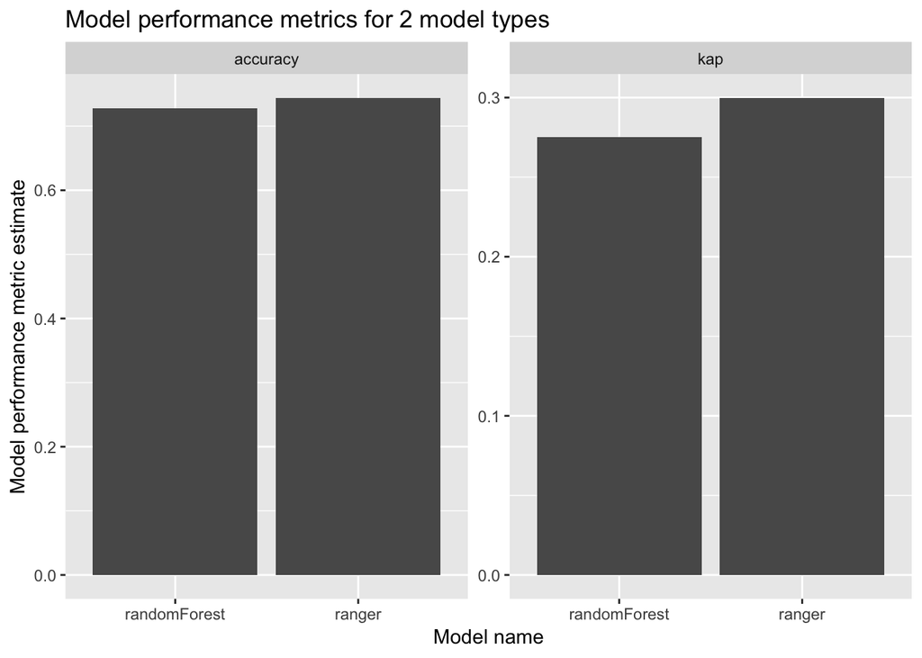

```r
# Let's plot the performance metrics by model type
all_model_results_credit %>%
  unnest(model_metrics) %>%
  ggplot(aes(x = model_name, y = .estimate)) +
  geom_bar(stat="identity") +
  facet_wrap(.~.metric,scales="free") +
  labs(x = "Model name",
       y = "Model performance metric estimate",
       title = "Model performance metrics for 2 model types")
```

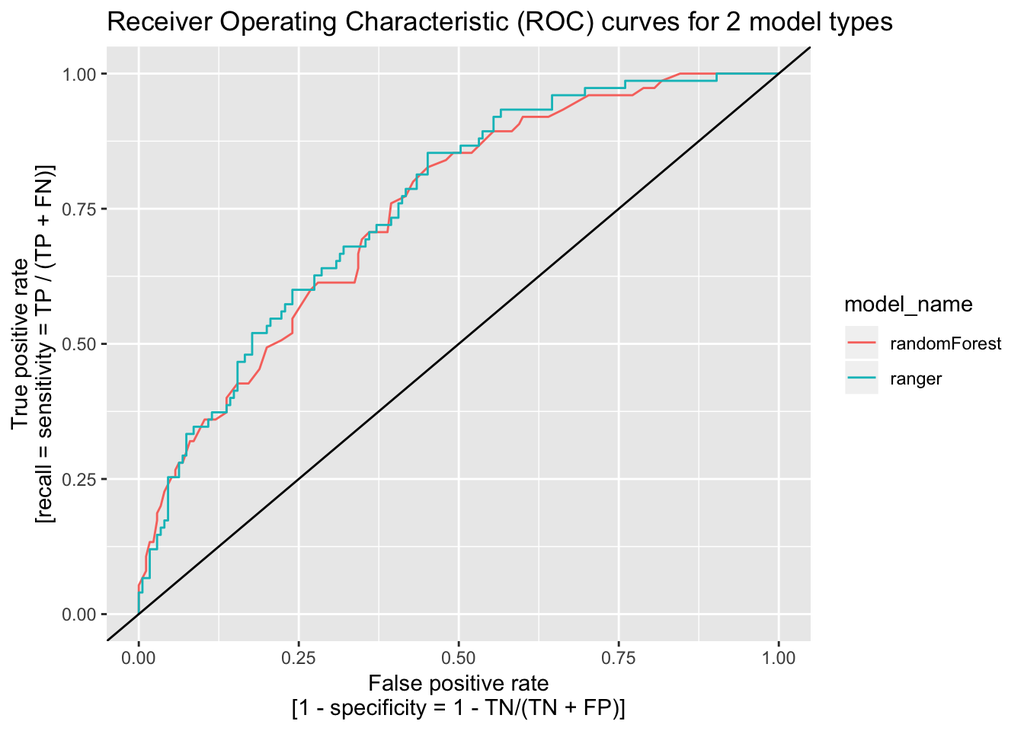

```r
# Let's also plot ROC curves by model type
all_model_results_credit %>%
  unnest(roc_curves) %>%
  ggplot(aes(x = 1-specificity,y=sensitivity,color=model_name)) +
  geom_line() +
  geom_abline(slope=1) +
  labs(title = "Receiver Operating Characteristic (ROC) curves for 2 model types",
    x = "False positive rate\n[1 - specificity = 1 - TN/(TN + FP)]",
    y = "True positive rate\n[recall = sensitivity = TP / (TP + FN)]")
```